# Reproducible Pitch Presentation

2024-04-04

## Gapminder Data Exploration

- **Presenter**: Vitalii Diakonov
- **Date**: 04/03/2024

This presentation introduces a Shiny application designed to explore various global health and economic indicators provided by the Gapminder dataset.

## Slide 2: The Gapminder Dataset

- **Global Data**: Life Expectancy, GDP per Capita, Population.
- **Insights**: Understand global trends over decades.
- **Application**: Visualize and analyze country-specific and global patterns.

The Gapminder dataset provides a unique lens through which we can observe the development and health of nations over time.

## Slide 3: Shiny Application Features

- **Interactive Exploration**: Users can select countries, continents, and time ranges to explore.
- **Dynamic Visualizations**: Life expectancy and GDP per capita over time.
- **User-Friendly Interface**: Designed for ease of use without sacrificing depth of analysis.

The application aims to make data exploration accessible and informative.

## Slide 4: Demonstrating the Application

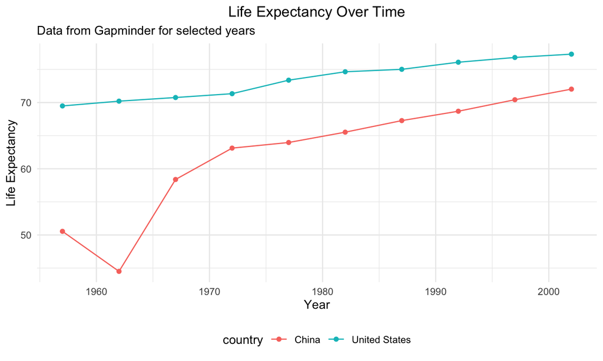

## Slide 5: Conclusion and Further Information

- **Goal**: Make data exploration engaging and accessible.
- **Learn More**: Visit [Gapminder](https://www.gapminder.org/data/) for more information on the dataset.
- **Try the App**: [Lifeapp](https://psydoc19.shinyapps.io/lifeapp/).

Thank you for your attention! For questions or further information, feel free to reach out.